# act_report

## Analysis and Insights

Weratedogs is a popular twitter account that rates people's dogs with funny comments abou the dog. Data from this account was wrangled using these steps:

- Gathering: the data was gathered using the twitter api, programatically downloaded and read from a frat file provided by udacity.
- Assessed: Assessment was done visually and programmatically using methods from the pandas library.
- Cleaned: Various quality and tidyness issues identified from the assessment were cleaned using pandas methods.

The dataset was then ready to be analysed, below are some of the insights gotten from this analysis.

### Insights

1. **What are the most popular dog names?**

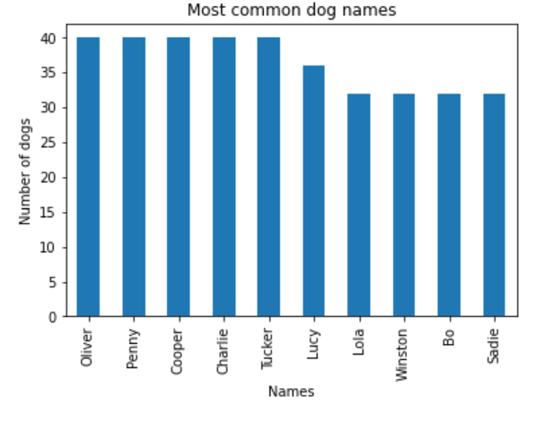

1. **How were the dog ratings distributed?**

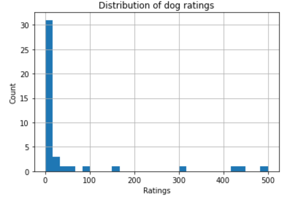

Weratedogs has a unique rating system, having the numerator larger than the denominator in alot of the ratings The distribution of the dog ratings was skewed to the right, most of the dogs rated in the dataset had ratings ranging from 0 to about 25, there were also a number of outliers in the rating ranging from about 100 to 500. This makes comparing the rating between dogs hard because they seam not to have been rated with the same scale.

1. **Is there a correlation between when a tweet was posted and the number of retweets it gets?**

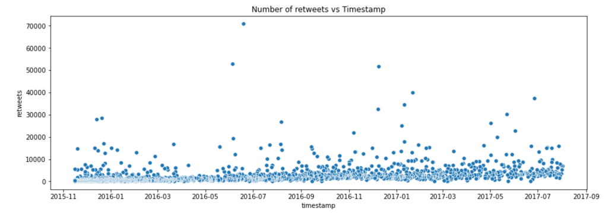